# Continent-wide tree fecundity driven by indirect climate effects | Nature Communications

# Continent-wide tree fecundity driven by indirect climate effects

[*Nature Communications*](https://www.nature.com/ncomms) **volume 12**, Article number: 1242 (2021) Cite this article

An [Author Correction](https://www.nature.com/articles/s41467-021-22025-2) to this article was published on 08 March 2021

## Abstract

Indirect climate effects on tree fecundity that come through variation in size and growth (climate-condition interactions) are not currently part of models used to predict future forests. Trends in species abundances predicted from meta-analyses and species distribution models will be misleading if they depend on the conditions of individuals. Here we find from a synthesis of tree species in North America that climate-condition interactions dominate responses through two pathways, i) effects of growth that depend on climate, and ii) effects of climate that depend on tree size. Because tree fecundity first increases and then declines with size, climate change that stimulates growth promotes a shift of small trees to more fecund sizes, but the opposite can be true for large sizes. Change the depresses growth also affects fecundity. We find a biogeographic divide, with these interactions reducing fecundity in the West and increasing it in the East. Continental-scale responses of these forests are thus driven largely by indirect effects, recommending management for climate change that considers multiple demographic rates.

## Introduction

The composition and structure of twenty-first century forests will depend on the seed production needed for tree populations to keep pace with climate change. North America is warming and drying out in much of the West. The dramatic impacts include large-scale die-backs<sup>1,2,3</sup> that are transforming size-species structure<sup>4,5</sup>. But the decade-scale trends will depend on the regeneration that follows tree death. Fecundity will determine the capacity of trees to disperse seed to the shifting habitats where they can survive in the future<sup>6,7,8</sup>; risks to each species depend not only on the current distribution of fecundity but also on its trajectory<sup>4,9,10,11,12,13</sup>. As with many ecological processes<sup>14,15,16</sup>, noisy, spatially variable fecundity trends are hard to quantify<sup>8,17</sup>, but this is only the first problem. Attributing trends to environmental variables is complicated by individual size, growth, and resource access<sup>18,19,20</sup>. Conservation efforts must anticipate not just the direct climate effects on this trajectory but also the indirect effects as growth and changing size structure also affect fecundity. Because it has thus far been impossible to estimate at continental scales, fecundity is the only major demographic process that lacks field-based estimates in models of vegetation change<sup>5,21,22</sup>. To address these challenges, we built the continental Masting Inference and Forecasting (MASTIF) network of primary data (Fig. 1), and we developed trend attribution (TA) to quantify climate impacts, as modulated by the condition of the organisms themselves. Application to the MASTIF network shows that indirect effects dominate, operating through stand structure and growth.

**Fig. 1: Longitudinal sites in the MASTIF network.**

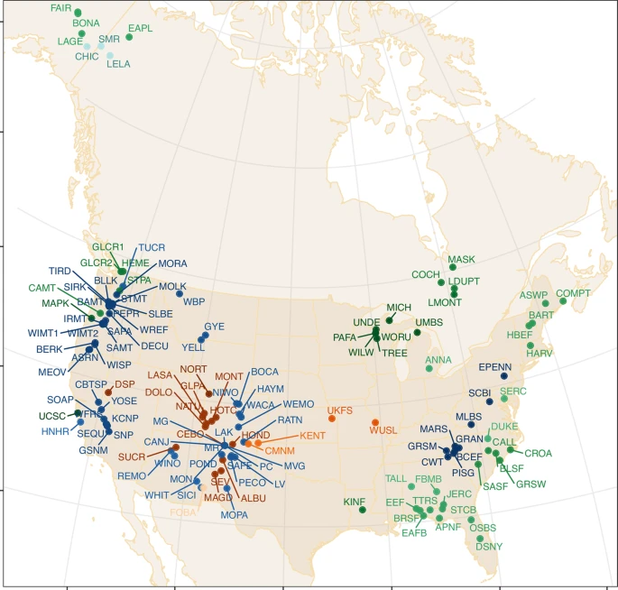

Colors match ecoregions in Fig. 3. Sites are listed by ecoregion in the Supplementary Data 1.

[Full size image](https://www.nature.com/articles/s41467-020-20836-3/figures/1)

Although a substantial climate-impacts literature has focused on growth responses to short-term (interannual to a decade) climate fluctuations<sup>3,23</sup>, this focus is not based on evidence that fecundity effects are of secondary importance. The emphasis on tree growth comes in part from the facts that (i) data are widely available from inventory plots and tree-ring records, (ii) where absent they can often be obtained from tree rings for long periods in the past, and (iii) growth anomalies can often be at least partly explained by climate anomalies<sup>3,23</sup>. By contrast, fecundity is not directly observed for most species and habitats, data accumulate slowly and with substantial investment, and the effects of climate anomalies can be overwhelmed by nonlinear, internal feedbacks on reproductive effort<sup>18,22,24,25,26,27</sup>. Although critical for population dynamics, a limited role for fecundity could be interpreted from stand simulators that stabilize dynamics by assuming an external seed pool<sup>28,29,30</sup>. This is done both for lack of estimates, but also because the contribution of fecundity to dynamics is too poorly understood to construct models that allow species to coexist; even models used to explore effects on species diversity depend on the assumption that seeds remain available even when adults are not<sup>30</sup>. Foundational understanding of population growth makes clear that fecundity contributes directly to fitness<sup>31,32,33</sup>, while the change in size can do so only indirectly. While evidence points to the direct importance of fecundity for future forests, we show here that it must be coupled with the indirect role of tree growth.

We identify and quantify the effects of climate change on fecundity at the continental scale, including the climate-condition interaction (CCI) that require individual-scale observations (Fig. 2). We hypothesized that climate change will be experienced by organisms, each in its own way. We use the term CCIs to include, for example, moisture effects that differ for deep-rooted adults and small saplings<sup>26,34</sup> and temperature effects that depend on light availability<sup>35</sup>. If CCIs are important, then they must be quantified at the scale of individuals. We find biogeographic differences in the indirect effects of climate change, slowing fecundity change in the West and increasing it in the East.

**Fig. 2: Trend attribution (TA) includes direct and indirect pathways for terms in Eq. (1).**

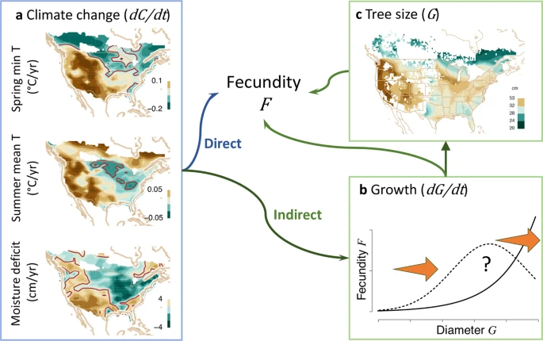

**a** Trends in climate variables (since 1990) include minimum *T* in spring, mean summer *T*, and moisture deficit (*D* = cumulative monthly PET-P). The brown contour separates positive and negative trends. Shaded contours are green (decreasing) to brown (increasing). **b** Indirect effects have two elements. An arrow from **b** to *F* includes a growth effect (d*G*/d*t*) and a climate-growth interaction (*C* × d*G*/d*t*). An arrow from **b** to **c** depends on the uncertain relationship between tree diameter *G* and fecundity *F* shown in panel (**b**). If fecundity continues to increase with tree size (solid line in **b**), then accelerated growth (orange arrows are d*G*/d*t*) moves trees into more productive size classes, but not if fecundity eventually declines (dashed line). **c** Average diameter of trees (restricted to trees >20 cm) is high in the West, meaning that the effects of tree growth depend on [if] fecundity continues to increase or declines with size in panel (**b**). The effect of size on fecundity (arrow from **c** to *F*) comes through an interaction with climate (*G* × d*C*/d*t* in Eq. (1)).

[Full size image](https://www.nature.com/articles/s41467-020-20836-3/figures/2)

## Results

TA was developed to quantify change that emerges from both direct and indirect effects and that are not amenable to traditional time-series methods. Effects of climate change are increasingly apparent, including shifts in phenology<sup>36</sup> and species range limits<sup>37,38</sup>. By contrast, the time series of species-abundance data typically lack a clear signal<sup>16,39,40</sup>. No ecological process suffers more from the signal-to-noise problem than seed production, where quasiperiodic, order-of-magnitude variation from year to year and tree to tree<sup>8,18,19,25,41,42</sup> can bury long-term trends. Autoregression models assume a fixed periodicity, but mast intervals are not fixed, not even within an individual<sup>25,35,43</sup>. There are as many time series as there are trees (>10<sup>5</sup> in this case), but they must be modeled together because there is dependence. Data are non-Gaussian (including zeros for immature trees and failed crops). Trends estimated by meta-analysis may not be comparable across studies due to divergent methods and transformations intended to force non-Gaussian data into traditional time-series models<sup>20</sup>. Efforts to determine whether a species is increasing or decreasing are further challenged by the uneven distribution of publications. A standard trend analysis of our sites (Fig. 3a) shows not one trend but rather a broad range, with most species (bars in Fig. 3b) increasing in some habitats while decreasing in others. Estimates are readily biased<sup>16</sup> due to haphazard habitat coverage (Fig. 3a).

**Fig. 3: Sites and species trends.**

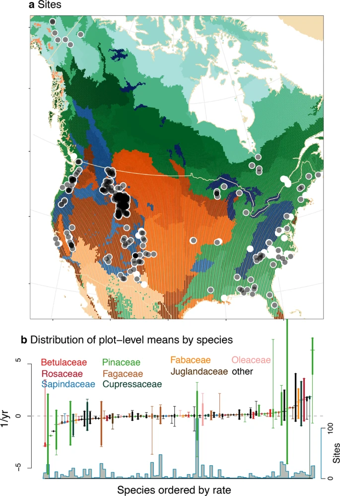

**a** Longitudinal studies in black (opacity proportional to numbers of sites) and opportunistic in white. Shaded ecoregions are desert/shrub/grass (browns), montane (blues), and mixed forest (greens). **b** Trends in mean log (proportionate) fecundity by species from sites in **a** range from negative (declining) to positive. As would be the case for any meta-analysis, the time scales for which trends are evaluated vary (see “Methods” section). Species belong to color-coded families below that are listed in Supplementary Data 2. There is no relationship with phylogeny (i.e., no trend in box color from left to right). Summaries in **b** include mean (crosshairs), 95% of site means (bold line), and range of site means (whiskers). The number of sites (*n*) contributing to **b** is shown below.

[Full size image](https://www.nature.com/articles/s41467-020-20836-3/figures/3)

The MASTIF network includes the primary tree-year data (a given tree in a given year) that are needed to estimate change and the contributions of CCI. Data include the canopy environment (fully exposed to deep shade) and tree size, recognizing that accelerated growth can speed reproductive maturity<sup>44</sup>. Ecological studies have assumed that fecundity continues to increase with stem diameter (Fig. 2b, solid line)<sup>45,46,47,48,49</sup>. However, horticultural practice suggests declines in large trees (Fig. 2b, dashed line), but the literature is limited<sup>50</sup>. Several ecological studies also suggest declines<sup>20,51,52,53</sup>, but inference suffers from few observations of large trees. The MASTIF network offers a broad range of sizes combined here with weighted regression methods that allowed us to quantify the effects of both maturation and eventual fecundity declines (see “Methods” section). Fecundity data include seed traps (STs) and crop counts (CCs) from longitudinal studies (Fig. 3a) and opportunistically through the iNaturalist MASTIF [https://www.inaturalist.org/projects/mastif] project, including 2,566,594 tree-years from 123 species. The dynamic model accommodates non-Gaussian data and serial and intertree dependence, with full uncertainty for data, model miss-specification, and parameters<sup>20</sup>. Continental prediction used 7,723,671 trees from inventory plots (see “Methods” section).

TA was developed to decompose direct and indirect effects on change. For transparency, three climate variables in Fig. 2a are represented here by a single state variable *C*. To evaluate community-wide effects, we report on log (proportionate) fecundity change,

$$\frac{{\mathrm{d}}f}{{\mathrm{d}}t}=\frac{1}{F}\frac{{\mathrm{d}}F}{{\mathrm{d}}t}=\frac{{\mathrm{d}}\mathrm{log}\,F}{{\mathrm{d}}t}$$

where *F* is seeds per tree per year. Proportionate change d*f*/d*t* is analyzed because we are interested in effects on species of both high and low fecundity. Analysis of absolute change d*F*/d*t* would be dominated by the few species that produce the most seeds. To obtain community change, we average these proportionate changes over all trees on a plot.

TA entails (i) model fitting and (ii) trend decomposition. Model fitting estimates responses as fitted coefficients. These responses are main effects of climate, ∂*f*/∂*C*, and size (diameter *G*), ∂*f*/∂*G*, and their interaction ∂*f*/∂(*G**C*). Trend decomposition combines these responses with dense information on the environment, including individual states (*G*, *C*) and their rates of change (d*G*/d*t*, d*C*/d*t*) (Fig. 2), summarized with three terms,

$$\frac{{{\mathrm{d}}f}}{{{\mathrm{d}}t}} = \overbrace {\frac{{\partial f}}{{\partial C}}\frac{{{\mathrm{d}}C}}{{{\mathrm{d}}t}}}^{{\mathrm{direct}}} + \overbrace {\underbrace {\frac{{\partial f}}{{\partial G}}\frac{{{\mathrm{d}}G}}{{{\mathrm{d}}t}}}_{{\mathrm{growth}}\,{\mathrm{effect}}} + \underbrace {\frac{{\partial f}}{{\partial \left( {GC} \right)}}\left( {G\frac{{{\mathrm{d}}C}}{{{\mathrm{d}}t}} + C\frac{{{\mathrm{d}}G}}{{{\mathrm{d}}t}}} \right)}_{{\mathrm{growth}} {\hbox{-}} {\mathrm{climate}}\,{\mathrm{interactions}}}}^{{\mathrm{indirect}}} + \underbrace \gamma _{{\mathrm{neither}}\,{\mathrm{growth}}\,{\mathrm{nor}}\,{\mathrm{climate}}}$$

(1)

Indirect terms are CCI, incorporating climate effects that are modulated by tree size, *G* × d*C*/d*t*, as when large, deep-rooted trees experience drought differently from saplings. Conversely, a change in growth rate has effects that can vary with climate, also a CCI, *C* × d*G*/d*t*. The indirect effects through growth *g*(*C*) = d*G*/d*t* are not shown in Eq. (1), but are given in the “Methods” section. Depending on how fecundity changes with size (Fig. 2b), climate stimulation of growth can move small trees into more fecund size classes. If fecundity eventually declines with size, growth has the opposite effect on large trees.

TA in Eq. (1) starts from a notion similar to “climate velocity”<sup>9,54</sup>, which replaces fecundity in Eq. (1) with distance *x* as d*x*/d*t* = d*x*/d*C* × d*C*/d*t*. Rather than distance-over-time in climate velocity, TA decomposes the climate and size contributions to fecundity trends over time. It relies on extracting the smooth trends from volatile seed production data. The terms in Eq. (1) are available each as a predictive distribution for each tree. There is an average over trees for each inventory plot. The climate effects on fecundity trends differ from sensitivity to interannual variation<sup>8,17,18,19,25,35</sup>. A species that reduces seed production in dry years (negative response to moisture deficit *D*<sub>*j*,*t*</sub> in Table S2.1) may not suffer from dry climates in general—indeed, the capacity to reallocate under fluctuating conditions can be adaptive. A negative effect in TA means that species and size classes of the current forests produce less seed under the decade-scale trends occurring now, based on responses across climate and habitat variation.

### Indirect effects dominate response

TA shows that continent-wide trends are dominated by indirect effects. Maps of these effect in Fig. 4 have different scales, which is necessary to show the geographic patterns within maps; the scale differences must be considered when comparing maps. The direct responses in Fig. 4a are transformed by the heterogeneity of climate trends (Fig. 4b) and then, indirectly, through tree growth (Fig. 4c). The responses in Fig. 4a are positive where trees dominate that have high mean fecundity responses. For example, trees that are most fecund under high spring *T* (Fig. 4a, top) and moisture deficit *D* (bottom) are concentrated in the Northwest (NW) and Southeast (SE).

**Fig. 4: Continent-wide causes for fecundity trends.**

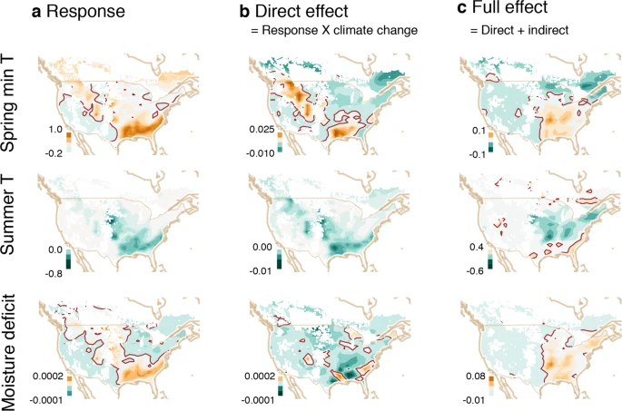

Shaded contours are green (decreasing) to brown (increasing). Responses to climate variables (∂*f*/∂*C*) in **a** are multiplied by climate change (×d*C*/d*t*) in Fig. 2a to give the direct effect (∂*f*/∂*C* × d*C*/d*t*) in panel (**b**) (first term of Eq. (1)). The direct effect in **b** is added to the indirect effect that comes through tree growth (terms 2 and 3 of Eq. (1)) to give the full effect in panel (**c**). Units are proportionate change in fecundity per °C or per mm[-month] moisture deficit in panel (**a**) and per year in panels (**b**, **c**). White areas lack inventory plots. The brown contour indicates zero.

[Full size image](https://www.nature.com/articles/s41467-020-20836-3/figures/4)

The direct responses in Fig. 4a are multiplied by heterogeneous climate change (Fig. 2a) to yield the direct effects (Fig. 4b). It is important to recognize that a positive effect of climate change occurs wherever the response to climate and the direction of climate change have the same sign. For example, the negative direct effects of spring *T* in the Northeast (NE) and Southwest (SW) (Fig. 4b, top) result from opposing forces: in the NE, mostly positive responses (Fig. 4a, top) combine with a negative spring *T* trend (Fig. 2a), that is, (+) × (−) = (−). In the SW, negative responses combine with a positive spring *T* trend, that is, (−) × (+) = (−). Between is a swath of positive effects stretching from the NW toward the SE (Fig. 4b, top), where positive responses overlap with rising spring *T* (Fig. 2a). The direct effects of other climate variables are near zero or negative for summer *T* (Fig. 4b, middle). The limited direct effects of moisture deficit *D* is apparent from the scale differences for maps in Fig. 4b.

The foregoing direct effects are overwhelmed by the indirect effects (contrast scales in Fig. 4b, c), both as main effects on growth in the second term and interactions in the third term of Eq. (1). Whereas the full effects contribute to a positive east/negative west divide in the effects of spring *T* (Fig. 4c, top) and moisture deficit *D* (Fig. 4c, bottom), the contribution of summer *T* is primarily negative in the East (Fig. 4c, center). Positive effects in the East come predominantly through spring *T* (Fig. 4c, top), which is transparent because both responses and climate trends tend to share the same sign (both positive: Figs. 2a and 4a, top). The full effects could not have been anticipated from the direct responses because they require consideration of how growth responds to climate and the effect of size and growth on fecundity.

To understand continental responses and the large differences between maps in Fig. 4b, c requires the decomposition of effects, which is available through the individual terms in Eq. (1). An important contributor to these differences is the pervasive fecundity declines that our analysis found for large trees (Fig. 5a). Due to management and species traits, growth stimulation in the East speeds the transition of small trees to larger, more fecund size classes (Fig. 5b). Conversely, much of the West supports trees that have passed this size. The East–West differences are amplified by maturation, which is increasing the probability of seed production in the East, but not the West (Supplementary Fig. S2.3b). Declining fecundity in large trees (which are also older in the West, Supplementary Fig. S2.3a) does not necessarily come from physiological decline (“senescence”) because [declines can result from] crown architectural changes also occur.

**Fig. 5: Indirect effects produce an East–West contrast.**

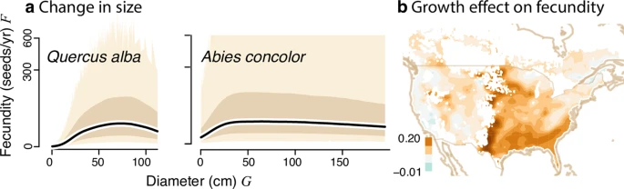

**a** Fecundity rising then falling with size, for a common eastern hardwood (*Q. alba*) and western conifer (*A. concolor*) plotted on the square root scale. The predictive mean (black line) is bounded by the 90% credible interval (dark shading) and the 90% predictive interval (light shading) over all tree-years. **b** The growth effect includes terms in Eq. (1) that are multiplied by d*G*/d*t*, that is, ∂*f*/∂*G* + ∂*f*/∂(*G**C*) × *C* (units are log *f*/yr). Averages shift from positive in the East to near zero or negative in the West, where more trees are near or past the diameter where growth stimulation increases fecundity.

[Full size image](https://www.nature.com/articles/s41467-020-20836-3/figures/5)

### Discussion

Continent-wide impacts of climate change are being governed by the indirect effects that come through the condition of individuals. Global change science has steadily improved understanding of direct responses, including photosynthetic rates, water use, and demography<sup>25,55,56</sup> and the abundances of species<sup>40</sup>. Lagging behind is the understanding of interactions and indirect effects<sup>18</sup>; individual responses to climate do not predict responses of canopies<sup>57</sup>, just as species responses do not predict outcomes of competition<sup>40</sup>. However, climate variation operates on individual organisms that see that change differently. From the multitude of individual traits that affect climate response, we show that size and growth differences provide important insights on continent-wide change. By combining detailed habitat change with the individual condition (Fig. 4), TA shows the dominance of indirect effects.

TA adds value to existing efforts because climate change is heterogeneous not only in rate but also in sign (Fig. 2). By exposing the trends masked by interannual and intertree volatility of seed production while incorporating effects of additional variables TA provides much-needed perspectives on patterns and processes that affect individuals. Because climate variables interact with one another and with the individual condition (CCI), models need to not only find coefficients for their effects (Fig. 4a) but also combine them with the changes in climate that are happening now (Fig. 4c). Current understanding suggests that fecundity is also responding to variables that could not be incorporated into this analysis, including changing CO<sub>2</sub><sup>44</sup>, irradiance and clouds<sup>59</sup>, and soils, depending only on data availability and distribution across sites.

TA can complement efforts based on stand simulators and species distribution models by quantifying contemporary change and extracting the reasons for it. For instance, because stand simulators rely on immigration to achieve species coexistence, fecundity estimates are mostly absent and without direct or indirect effects of climate that are based on field data. TA combines growth with fecundity estimates at the tree-year scale for understanding biogeographic consequences, thus offering an alternative perspective to stand simulators and map-based predictions of future biodiversity<sup>60</sup>.

The finding that fecundity can decline in large trees, with biogeographic consequences, does not diminish their contribution to biological diversity through microhabitats for wildlife<sup>61</sup>. Selective removals that promote uneven-aged structures can preserve microhabitats and promote canopy heterogeneity and light penetration that stimulates growth and fecundity<sup>35</sup>. Growth is not currently making a strong contribution to average trends in the West; however, management priorities can be guided by disaggregating these mean trends to understand their distribution across species at risk and/or valued for their ecosystem services.

The determination that indirect effects through individual condition can dominate biogeographic responses has immediate application in forestry and conservation. As an example, scientists and managers increasingly recognize that the challenges posed by continuing trends in climate cannot be addressed with traditional nursery practice or silvicultural treatments<sup>62</sup>. Managing for long-term trends (as opposed to the volatile interannual variation) must consider both the direct effect of climate-induced changes on growth and the indirect effects of these changes on fecundity. This knowledge is critical because size-species structure is often under the direct control of forest managers and conservation planners, especially in eastern North America<sup>63</sup>, whereas climate is not<sup>4</sup>. TA offers concrete estimates of how fast these changes are happening now and which variables are responsible. While climate is not controllable by managers, the opportunity to influence indirect effects through stand structure can foster stronger connections between conservation planning and global change science.

## Methods

### Elements of TA

Identifying biogeographic trends within volatile data required several innovations in the MASTIF model<sup>20</sup>, building from multivariate state-space methods in previous applications<sup>41,52</sup>. Standard modeling options, such as generalized linear models and their derivatives, do not accommodate key features of the masting processes. First, multiple data types are not independent. Maturation status is binary with detection error, CCs are non-negative integers, also with detection error, and STs require a transport model (dispersal) linking traps to trees, and identification error in seed identification. Of course, a tree observed to bear seed, now or in the past, is known to be mature now. However, failure to observe seed does not mean that an individual is immature because there are detection errors and failed crop years<sup>41,64</sup>.

Second, seed production is quasiperiodic within an individual (serial dependence), quasi-synchronous between individuals (“mast years”), [and] there is dependence on environmental variation, and massive variation within and between trees<sup>41,53,65</sup>. Autoregressive error structures (AR(*p*) for *p* lag terms) impose a rigid assumption of dependence that is not consistent with quasiperiodic variation that can drift between dominant cycles within the same individual over time<sup>43</sup>. It does not allow for individual differences in mast periodicity.

Third, climate variables that affect fecundity operate both through interannual anomalies over time and as [a] geographic variation. The masting literature deals almost exclusively with the former, but our application must identify the latter: the potentially smooth variation of climate effects across regions must be extracted from the many individual time series, each dominated by local “noise.”

Finally, model fitting is controlled by the size classes that dominate a given site and thus is insensitive to size classes that are poorly represented. Large trees are relatively rare in eastern forests, making it hard to identify potential declines in large, old individuals<sup>41,53</sup>. Conversely, the shade-intolerant species that dominate second-growth forests often lack the smaller size classes needed to estimate maturation and early stages where fecundity may be increasing rapidly.

Several of the foregoing challenges are resolved in the MASTIF model by introducing latent states for individual maturation status and tree-year seed production. The dependent data types (maturation status, CCs, STs) become conditionally independent in the hierarchical MASTIF model (e.g., ref. <sup>66</sup>). The serial dependence is handled as a conditional hidden Markov process for maturation that combines with CCs and STs by way of stochastic (latent) conditional fecundity. Maturation status and conditional fecundity must be estimated jointly, that is, not with separate models. The latent maturation/fecundity treatment avoids imposing a specific AR(*p*) structure. In the MASTIF model there is a posterior covariance in maturation/fecundity across all tree-year estimates that need not adhere to any specific assumption<sup>20</sup>. The dependence across individuals and years is automatic and available from the posterior distribution.

Separating the spatial from temporal components of climate effects is possible here, not only because the entire network is analyzed together but also because predictors in the model include both climate norms for the individual sites and interannual anomalies across sites<sup>35,52</sup>. TA depends on both of these components.

To optimize inference on size effects, the sampling of coefficients in posterior simulation is implemented as a weighted regression. This means that the contribution of tree diameter to fecundity is inversely proportional to the abundance of that size class in the data. This approach has the effect of balancing the contributions of abundant and rare sizes. Identifying size effects further benefits from the introduction of opportunistic field sampling, which can target the large individuals that are typically absent from field study plots.

### MASTIF data network

Data included in the analysis come from published and unpublished sources and offer one or both of the two data types, CCs and STs (Supplementary Data 1). Both data types inform tree-year fecundity; they are plotted by year in Fig. 6.

**Fig. 6: Distribution of observation trees by year in the North American region of the MASTIF network.**

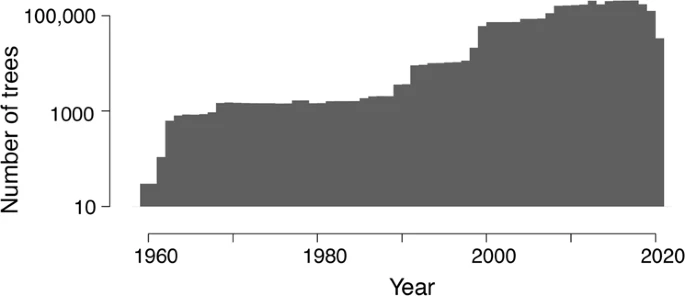

[Full size image](https://www.nature.com/articles/s41467-020-20836-3/figures/6)

CCs in the MASTIF network are obtained by one of three methods. Most common are counts with binoculars that are recorded with an estimate of the fraction of the crop that was observed. A second CC method makes use of seeds collected per ground surface area relative to the crown area. This method is used where conspecific crowns are isolated and wind dispersal is limited. The crop fraction is the ratio of ground area for traps relative to the projected crown area. Examples include HNHR<sup>67</sup> and BCEF<sup>68</sup>.

A third CC method is based on evidence for past cone production that is preserved on trees. This has been used for *Abies balsamea* at western Quebec sites<sup>69</sup>, *Pinus ponderosa* in the Rocky Mountains<sup>70</sup>, and for *Pinus edulis* at SW sites<sup>27</sup>.

ST data include observations on individual trees that combine with seed counts from traps. Because individual studies can report different subcategories of seeds, and few conduct rigorous tests of viability, we had to combine them using the closest description to the concept of “viable”. For example, we do not include empty conifer seeds. A dispersion model provides estimates of seeds derived from each tree. ST and CC studies are listed in Supplementary Data 1. The likelihoods for CCs and STs are detailed in ref. <sup>20</sup>. Individually and in combination, the two data types provide estimates, with full uncertainty, for fecundity across all tree-years.

### Covariates

[Full size table](https://www.nature.com/articles/s41467-020-20836-3/tables/1)

To distinguish between the effects of spatial variation versus interannual variability, spring *T* and moisture *D* are included in the model as site means and site anomalies<sup>35</sup>. Spring minimum *T* affect phenology and frost risk during flowering and early fruit initiation. Summer mean *T* (June–August) is included both as a linear and quadratic term. Mean summer *T* is linked to thermal energy availability during the growing season, with the quadratic term allowing for potential suppression due to extreme heat. Moisture *D* (cumulative monthly PET-*P* (potential evapotranspiration[-] minus precipitation) for January–August) is included as a site mean and an annual anomaly. Moisture *D* is important for carbon assimilation and fruit development during summer in the eastern continent and, additionally, from the preceding winter in the western continent. For species that develop over spring and summer, anomalies incorporate the current and previous year. We did not include longer lags in covariates. For species that disperse seed in spring (*Ulmus* spp. and some members of *Acer*), only the previous year was used. Temperature anomalies were included for spring, but not summer, simply to reduce the number of times that temperature variables enter the model, and these two variables tended to be correlated at many sites.

Climate covariates were derived from gridded climate products and combined with local climate monitoring where it is available. Terraclimate<sup>71</sup> provides monthly resolution, but it is spatially coarse. For both norms and trends, we used the period from 1990 to 2019 because global temperatures have been increasing consistently since the 1980s, and this span broadly overlaps with fecundity data (Fig. 6). CHELSA<sup>72</sup> data are downscaled to a 1 km grid, but it does not extend to 2019. Our three-component climate scaling used regression to project CHELSA forward using Terraclimate, followed by downscaling to 1 km with CHELSA, with further downscaling to local climate data. Even where local climate data exist, they often do not span the full duration of field studies, making the link to gridded climate data important. Local climate data were especially important for mountainous sites in the Appalachians, Rockies, Sierra Nevada, and Cascades.

Of the full list of variables, a subset was retained, depending on species (some have narrow geographic ranges) and deviance information criteria of the fitted model (Supplementary Data 2). Year effects in the model allow for the interannual variation that is not absorbed by anomalies<sup>20</sup>.

### Model fitting and TA

As mentioned above, model fitting applied the hierarchical Bayes model of ref. <sup>20</sup> to the combination of time series and opportunistic observations summarized in Fig. 1. Posterior simulation was completed with Markov chain Monte Carlo based on direct sampling, Metropolis, and Hamiltonian Markov chain. Model fitting used 211,146 trees and 2,566,594 tree-years from 123 species (Supplementary Data 2). Only species with multiple observation years were included.

### General form for TA

Equation 1 simplifies the model to highlight direct and indirect effects. Again, climate variables and tree size represent only a subset of the predictors in the model that are collected in a design vector \({{\bf{x}}}_{t}=[{x}_{1,t},\ldots ,{x}_{Q,t}]^{\prime}\), where the *q* = 1, …, *Q* predictors include shading from local competition, individual size, and climate and habitat variables (Table 1). On the proportionate scale, Eq. (1) can be written in terms of all predictors, including main effects and interactions, as

$$\frac{{\mathrm{d}}f}{{\mathrm{d}}t}=\mathop{\sum }\limits_{q=1}^{Q}\left(\frac{\partial f}{\partial {x}_{q}}+\sum _{q^{\prime} \in {I}_{q}}\frac{\partial f}{\partial ({x}_{q}{x}_{q^{\prime} })}{x}_{q^{\prime} }\right)\frac{{\mathrm{d}}{x}_{q}}{{\mathrm{d}}t}+\gamma$$

(2)

where *I*<sub>*q*</sub> are variables that interact with *x*<sub>*q*</sub>. In this application, interactions include tree diameter with moisture deficit and diameter squared. Each term in the summation consists of a main effect of *x*<sub>*q*</sub> and interactions that are multiplied by the rate of change in variable *x*<sub>*q*</sub>. For the simple case of only two predictors, Eq. (2) is recognizable as Eq. (1) of the main text, where *x*<sub>1</sub>, *x*<sub>2</sub> have been substituted for variables *G* and *C*. In our application, predictors include additional climate and shading (Table 1).

Recognizing that environmental variables affect not only fecundity but also growth rate, we extract the size effect, that is, the *x*<sub>*q*</sub> that is *G*, and incorporate these indirect effects (through growth) by expanding *g* = d*G*/d*t* in Eq. (1) of the main text as

$$g=\mathop{\sum }\limits_{q=1}^{Q}\left(\frac{\partial g}{\partial {x}_{q}}+\mathop{\sum}\limits _{q^{\prime} \in {I}_{q}}\frac{\partial g}{\partial ({x}_{q}{x}_{q^{\prime} })}{x}_{q^{\prime} }\right){x}_{q}+\nu$$

(3)

where *ν* is the component of growth that is not accommodated by other terms. This expression allows us to evaluate the full effect of climate variables, including those coming indirectly through growth.

### Connecting fitted coefficients in MASTIF to TA

$${f}_{ij}(t)={\mathrm{log}}\,{F}_{ij}(t)={\mathrm{log}}\,{\rho }_{ij}(t)+{\mathrm{log}}\,{\psi }_{it}(t)$$

(4)

The corresponding rate equation is

$$\frac{{\mathrm{d}}f}{{\mathrm{d}}t}=\frac{{\mathrm{d}}\,{\mathrm{log}}\,\rho }{{\mathrm{d}}t}+\frac{{\mathrm{d}}\,{\mathrm{log}}\,\psi }{{\mathrm{d}}t}$$

(5)

The discretized and stochasticized version of Eq. (1) is

$$\frac{{\mathrm{d}}{F}_{ij}}{{\mathrm{d}}t} = \, \frac{{F}_{ij,t+{\mathrm{d}}t}-{F}_{ij,t}}{{\mathrm{d}}t}+{\epsilon }_{ij,t}\\ = \, {{\Delta }}{F}_{ij,t}+{\epsilon }_{ij,t}$$

(6)

where d*t* = 1 and *ϵ*<sub>*i**j*,*t*</sub> is the integration error. When applied to a dynamic process model, this term further absorbs process error (see above), which is critical here to allow for conditional independence where observations are serially dependent. In simplest terms, *ϵ* is model miss-specification that allows for dependence in data.

The MASTIF model that provides estimates for TA is detailed in ref. <sup>20</sup>. Elements of central interest for TA are

$${F}_{ij,t} = \, {z}_{ij,t}{\psi }_{ij,t}\\ \left[{z}_{ij,t}=1\right] \sim \, {{Bernoulli}}\left({\rho }_{ij,t}\right)\\ {\rho }_{ij,t} = \, {{\Phi }}({{\boldsymbol{\mu }}}_{ij,t})\\ \mathrm{log}\,{\psi }_{ij,t} = \,{{\bf{x}}}_{ij,t}^{\prime}{\boldsymbol{\beta }}+{h}_{t}\left(T\right)+{\epsilon }_{ij,t}$$

where *μ*<sub>*i**j*,*t*</sub> = *α*<sub>0</sub> + *α*<sub>*G*</sub>*G*<sub>*i**j*,*t*</sub> describes the increase in maturation probability with size, Φ(⋅) is the standard normal distribution function (a probit), *ϵ*<sub>*i**j*,*t*</sub> ~ *N*(0, *σ*<sup>2</sup>), and *h*<sub>*t*</sub>(*T*) can include year effects, *h*(*T*) = *κ*<sub>*t*</sub>, or lagged effects, \(h(T)=\mathop{\sum }\nolimits_{k = 1}^{p}{\kappa }_{k}{\psi }_{ij,t-k}\), that contribute to *γ* in Eq. (1) of the main text. If year effects are used, then *γ* includes the trend in year effects. (The generative version of this model writes individual states at *t* conditional on *t* − 1 and is given in the Supplement to ref. <sup>20</sup>.). If an AR(*p*) model is used, then *γ* = *κ*<sub>1</sub> (provided data are not detrended). Random individual effects in the fitted model are marginalized for prediction of trees that were not fitted, meaning that *σ*<sup>2</sup> is the sum of model residual and random-effects variance. Again, the length-*Q* design vector **x**<sub>*i**j*,*t*</sub> includes individual attributes (e.g., diameter *G*<sub>*i**j*,*t*</sub>), local competitive environment, and climate (Table 1). There is a corresponding coefficient vector *β*.

Moving to a difference equation (rate of change) for conditional log fecundity,

$${{\Delta }}{f}_{ij,t}={{\Delta }}\mathrm{log}\,{\rho }_{ij,t}+{{\Delta }}\mathrm{log}\,{\psi }_{ij,t}$$

where

$${{\Delta }}\mathrm{log}\,{\psi }_{ij,t} =\mathrm{log}\,{\psi }_{ij,t+1}-\mathrm{log}\,{\psi }_{ij,t}\\ ={{\Delta }}{{\bf{x}}}_{ij,t}^{\prime}{\boldsymbol{\beta }}+{\gamma }_{ij,t}+{\nu }_{ij,t}\\ {{\Delta }}{{\bf{x}}}_{ij,t} ={{\bf{x}}}_{i,t}-{{\bf{x}}}_{ij,t-1}\\ {\nu }_{ij,t} \sim N(0,2{\sigma }^{2})$$

The variance in the last line is the variance of the difference Δ*ϵ*<sub>*i**j*,*t*</sub>.

Elements of basic theory in Eq. (1) of the main text are linked to data through the modeling framework as

$${{\Delta }}{f}_{ij,t}= +{\beta }_{{T}_{sp}}{{\Delta }}{T}_{sp,j}\\ +\left({\beta }_{T}+2{\beta }_{{T}^{2}}{T}_{j}\right){{\Delta }}{T}_{j}\\ +\left({\beta }_{D}+{\beta }_{GD}{G}_{ij,t}\right){{\Delta }}{D}_{j}\\ +\left({\alpha }_{G}\frac{\phi ({{\boldsymbol{\mu }}}_{ij,t})}{{{\Phi }}({{\boldsymbol{\mu }}}_{ij,t})}+{\beta }_{G}+2{\beta }_{{G}^{2}}{G}_{ij,t}+{\beta }_{GD}{D}_{j}\right){{\Delta }}{G}_{ij}\\ +{\gamma }_{ij,t}+{\nu }_{ij,t}$$

(7)

where *ϕ*(⋅) is the standard normal density function that comes from the rate of progress toward maturation. Again, the anomalies do not appear in this expression for trends because trends in the anomalies and year effects enter through *γ*.

**Fig. 7: Size and maturation effects on fecundity.**

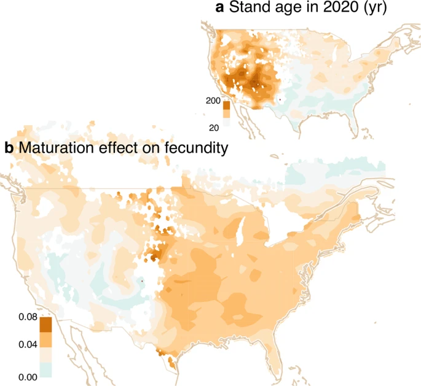

[Full size image](https://www.nature.com/articles/s41467-020-20836-3/figures/7)

All terms in Eq. (7) have units of mean change in proportionate fecundity, and these are mapped in figures of the main text. We focus on proportionate fecundity because it reflects the full effect of climate as opposed to total fecundity, which would often be dominated by one or a few trees of a single species. However, from proportionate fecundity we can obtain change in fecundity as Δ*F*<sub>*i**j*,*t*</sub> = *F*<sub>*i**j*,*t*</sub> × Δ*f*<sub>*i**j*</sub>. Stand-level effects on fecundity change at site *j* can be obtained from individual change as

$${{\Delta }}{F}_{j}=\mathop{\sum }\limits_{i=1}^{{n}_{j}}{{\Delta }}{F}_{ij}=\mathop{\sum }\limits_{i=1}^{{n}_{j}}{F}_{ij}{{\Delta }}{f}_{ij,t}$$

Again, maps in Fig. 5 show mean proportionate effects for all trees on an inventory plot.

### Reporting summary

Further information on research design is available in the Nature Research Reporting Summary linked to this article.

## Data availability

Data from the study are available at the Duke Data Repository (Dataset) [https://doi.org/10.7924/r4348ph5t].

## Code availability

Code in R and C++ is available on CRAN as mastif version 1.0.1 [https://cran.r-project.org/web/packages/mastif/index.html], with additional background here.

## Change history

### 10 March 2021

- A Correction to this paper has been published: https://doi.org/10.1038/s41467-021-22025-2

## References

1. 1.

   Schwantes, A. M. et al. Measuring canopy loss and climatic thresholds from an extreme drought along a fivefold precipitation gradient across texas. *Glob. Change Biol.* **23**, 5120–5135 (2017).

   [ADS](http://adsabs.harvard.edu/cgi-bin/nph-data_query?link_type=ABSTRACT&bibcode=2017GCBio..23.5120S) Google Scholar
2. 2.

   Seidl, R. et al. Forest disturbances under climate change. *Nat. Clim. Change* **7**, 395–402 (2017).

   [ADS](http://adsabs.harvard.edu/cgi-bin/nph-data_query?link_type=ABSTRACT&bibcode=2017NatCC...7..395S) [Google Scholar](http://scholar.google.com/scholar_lookup?&title=Forest%20disturbances%20under%20climate%20change&journal=Nat.%20Clim.%20Change&volume=7&pages=395-402&publication_year=2017&author=Seidl%2CR)
3. 3.

   Williams, A. P. et al. Large contribution from anthropogenic warming to an emerging North American megadrought. *Science* **368**, 314–318 (2020).

   [ADS](http://adsabs.harvard.edu/cgi-bin/nph-data_query?link_type=ABSTRACT&bibcode=2020Sci...368..314W) [CAS](https://www.nature.com/articles/cas-redirect/1%3ACAS%3A528%3ADC%252BB3cXntl2qt7Y%253D) Google Scholar
4. 4.

   Clark, J. S. et al. The impacts of increasing drought on forest dynamics, structure, and biodiversity in the united states. *Glob. Change Biol.* **22**, 2329–2352 (2016).

   [ADS](http://adsabs.harvard.edu/cgi-bin/nph-data_query?link_type=ABSTRACT&bibcode=2016GCBio..22.2329C) Google Scholar
5. 5.

   McDowell, N. et al. Pervasive shifts in forest dynamics in a changing world. *Science* (in the press).
6. 6.

   Ibanez, I., Clark, J. S. & Dietze, M. C. Evaluating the sources of potential migrant species: implications under climate change. *Ecol. Appl.* **18**, 1664–1678 (2008).

   Google Scholar
7. 7.

   Rogers, B. M., Jantz, P. & Goetz, S. J. Vulnerability of eastern us tree species to climate change. *Glob. Change Biol.* **23**, 3302–3320 (2017).

   [ADS](http://adsabs.harvard.edu/cgi-bin/nph-data_query?link_type=ABSTRACT&bibcode=2017GCBio..23.3302R) Google Scholar
8. 8.

   Ascoli, D. et al. Inter-annual and decadal changes in teleconnections drive continental-scale synchronization of tree reproduction. *Nat. Commun.* **8**, https://doi.org/10.1038/s41467-017-02348-9 (2017).
9. 9.

   Loarie, S. R. et al. The velocity of climate change. *Nature* **462**, 1052–1055 (2009).

   [ADS](http://adsabs.harvard.edu/cgi-bin/nph-data_query?link_type=ABSTRACT&bibcode=2009Natur.462.1052L) [CAS](https://www.nature.com/articles/cas-redirect/1%3ACAS%3A528%3ADC%252BD1MXhs1SktbvJ) [Google Scholar](http://scholar.google.com/scholar_lookup?&title=The%20velocity%20of%20climate%20change&journal=Nature&volume=462&pages=1052-1055&publication_year=2009&author=Loarie%2CSR)
10. 10.

    Zhu, K., Woodall, C. & Clark, J. Failure to migrate: lack of tree range expansion in response to climate change. *Glob. Change Biol.* **18**, 1042–1052 (2011).

    [ADS](http://adsabs.harvard.edu/cgi-bin/nph-data_query?link_type=ABSTRACT&bibcode=2012GCBio..18.1042Z) Google Scholar
11. 11.

    Dobrowski, S. Z. & Parks, S. A. Climate change velocity underestimates climate change exposure in mountainous regions. *Nat. Commun.* **7**, 12349 (2016).

    [ADS](http://adsabs.harvard.edu/cgi-bin/nph-data_query?link_type=ABSTRACT&bibcode=2016NatCo...712349D) [CAS](https://www.nature.com/articles/cas-redirect/1%3ACAS%3A528%3ADC%252BC28XhtlSgsr7F) [PubMed](http://www.ncbi.nlm.nih.gov/entrez/query.fcgi?cmd=Retrieve&db=PubMed&dopt=Abstract&list_uids=4974646) [PubMed Central](http://www.ncbi.nlm.nih.gov/pmc/articles/PMC4974646) Google Scholar
12. 12.

    Ettinger, A. & Hillerislambers, J. Competition and facilitation may lead to asymmetric range shift dynamics with climate change. *Glob. Change Biol.* **23**, 3921–3933 (2017).

    [ADS](http://adsabs.harvard.edu/cgi-bin/nph-data_query?link_type=ABSTRACT&bibcode=2017GCBio..23.3921E) Google Scholar
13. 13.

    Fei, S. et al. Divergence of species responses to climate change. *Sci. Adv.* **3**, e1603055 (2017).

    [ADS](http://adsabs.harvard.edu/cgi-bin/nph-data_query?link_type=ABSTRACT&bibcode=2017SciA....3E3055F) [PubMed](http://www.ncbi.nlm.nih.gov/entrez/query.fcgi?cmd=Retrieve&db=PubMed&dopt=Abstract&list_uids=5435420) [PubMed Central](http://www.ncbi.nlm.nih.gov/pmc/articles/PMC5435420) [Google Scholar](http://scholar.google.com/scholar_lookup?&title=Divergence%20of%20species%20responses%20to%20climate%20change&journal=Sci.%20Adv.&volume=3&publication_year=2017&author=Fei%2CS)
14. 14.

    Lister, B. C. & Garcia, A. Climate-driven declines in arthropod abundance restructure a rainforest food web. *Proc. Natl Acad. Sci. USA* **115**, E10397–E10406 (2018).

    [CAS](https://www.nature.com/articles/cas-redirect/1%3ACAS%3A528%3ADC%252BC1cXitVyhs7vP) Google Scholar
15. 15.

    Seibold, S. et al. Arthropod decline in grasslands and forests is associated with landscape-level drivers. *Nature* **574**, 671–674 (2019).

    [ADS](http://adsabs.harvard.edu/cgi-bin/nph-data_query?link_type=ABSTRACT&bibcode=2019Natur.574..671S) [CAS](https://www.nature.com/articles/cas-redirect/1%3ACAS%3A528%3ADC%252BC1MXitV2hsbfK) Google Scholar
16. 16.

    van Klink, R. et al. Meta-analysis reveals declines in terrestrial but increases in freshwater insect abundances. *Science* **368**, 417–420 (2020).

    [ADS](http://adsabs.harvard.edu/cgi-bin/nph-data_query?link_type=ABSTRACT&bibcode=2020Sci...368..424K) Google Scholar
17. 17.

    Koenig, W. D. & Knops, J. M. H. The mystery of masting in trees: some trees reproduce synchronously over large areas, with widespread ecological effects, but how and why? *Am. Scientist* **93**, 340–347 (2005).

    Google Scholar
18. 18.

    Berdanier, A. B. & Clark, J. S. Divergent reproductive allocation trade-offs with canopy exposure across tree species in temperate forests. *Ecosphere* **7**, e01313 (2016).

    Google Scholar
19. 19.

    Davi, H. et al. Disentangling the factors driving tree reproduction. *Ecosphere* **7**, e01389 (2016).

    [Google Scholar](http://scholar.google.com/scholar_lookup?&title=Disentangling%20the%20factors%20driving%20tree%20reproduction&journal=Ecosphere&volume=7&publication_year=2016&author=Davi%2CH)
20. 20.

    Clark, J. S., Nunez, C. & Tomasek, B. Foodwebs based on unreliable foundations: spatiotemporal masting merged with consumer movement, storage, and diet. *Ecol. Monogr.* **89**, e01381 (2019).

    Google Scholar
21. 21.

    Fisher, R. A. et al. Vegetation demographics in earth system models: a review of progress and priorities. *Glob. Change Biol.* **24**, 35–54 (2018).

    [ADS](http://adsabs.harvard.edu/cgi-bin/nph-data_query?link_type=ABSTRACT&bibcode=2018GCBio..24...35F) Google Scholar
22. 22.

    Vacchiano, G. et al. Reproducing reproduction: How to simulate mast seeding in forest models. *Ecol. Model.* **376**, 40–53 (2018).

    Google Scholar
23. 23.

    Pederson, N. et al. A framework for determining population-level vulnerability to climate: evidence for growth hysteresis in chamaecyparis thyoides along its contiguous latitudinal distribution. *Front. For. Glob. Change* **3**, https://www.frontiersin.org/article/10.3389/ffgc.2020.00039 (2020).
24. 24.

    Herrera, C. M., Jordano, P., Guitian, J. & Traveset, A. Annual variability in seed production by woody plants and the masting concept: reassessment of principles and relationship to pollination and seed dispersal. *Am. Naturalist* **152**, 576–594 (1998).

    [CAS](https://www.nature.com/articles/cas-redirect/1%3ASTN%3A280%3ADC%252BD1cnit1yntw%253D%253D) Google Scholar
25. 25.

    Hacket-Pain, A. J., Friend, A. D., Lageard, J. G. & Thomas, P. A. The influence of masting phenomenon on growth-climate relationships in trees: explaining the influence of previous summers’ climate on ring width. *Tree Physiol.* **35**, 319–330 (2015).

    Google Scholar
26. 26.

    Bogdziewicz, M., Fernández-Martínez, M., Espelta, J., Ogaya, R. & Penuelas, J. Is forest fecundity resistant to drought? Results from an 18-yr rainfall-reduction experiment. *N. Phytologist* https://doi.org/10.1111/nph.16597 (2020).
27. 27.

    Wion, A. P., Weisberg, P. J., Pearse, I. S. & Redmond, M. D. Aridity drives spatiotemporal patterns of masting across the latitudinal range of a dryland conifer. *Ecography* **43**, 569–580 (2020).

    Google Scholar
28. 28.

    Pacala, S. W. et al. Forest models defined by field measurements: estimation, error analysis and dynamics. *Ecol. Monogr.* **66**, 1–43 (1996).

    Google Scholar
29. 29.

    Maréchaux, I. & Chave, J. An individual-based forest model to jointly simulate carbon and tree diversity in amazonia: description and applications. *Ecol. Monogr.* **87**, 632–664 (2017).

    Google Scholar
30. 30.

    Rüger, N. et al. Demographic trade-offs predict tropical forest dynamics. *Science* **368**, 165–168 (2020).

    [ADS](http://adsabs.harvard.edu/cgi-bin/nph-data_query?link_type=ABSTRACT&bibcode=2020Sci...368..165R) [Google Scholar](http://scholar.google.com/scholar_lookup?&title=Demographic%20trade-offs%20predict%20tropical%20forest%20dynamics&journal=Science&volume=368&pages=165-168&publication_year=2020&author=R%C3%BCger%2CN)
31. 31.

    Grubb, P. J. The maintenance of species-richness in plant communities: the importance of the regeneration niche. *Biol. Rev.* **52**, 107–145 (1977).

    Google Scholar
32. 32.

    Clark, J. S. et al. Interpreting recruitment limitation in forests. *Am. J. Bot.* **86**, 1–16 (1999).

    [CAS](https://www.nature.com/articles/cas-redirect/1%3ASTN%3A280%3ADC%252BC3MnhtlGhtg%253D%253D) [Google Scholar](http://scholar.google.com/scholar_lookup?&title=Interpreting%20recruitment%20limitation%20in%20forests&journal=Am.%20J.%20Bot.&volume=86&pages=1-16&publication_year=1999&author=Clark%2CJS)
33. 33.

    Clark, C. J., Poulsen, J. R., Levey, D. J. & Osenberg, C. W. Are plant populations seed limited? A critique and meta analysis of seed addition experiments. *Am. Naturalist* **170**, 128–142 (2007).

    [CAS](https://www.nature.com/articles/cas-redirect/1%3ASTN%3A280%3ADC%252BD2srjvVCqsA%253D%253D) Google Scholar
34. 34.

    Mackay, D. S. et al. Conifers depend on established roots during drought: results from a coupled model of carbon allocation and hydraulics. *N. Phytologist* **225**, 679–692 (2020).

    [CAS](https://www.nature.com/articles/cas-redirect/1%3ACAS%3A528%3ADC%252BB3cXntV2gsw%253D%253D) Google Scholar
35. 35.

    Clark, J. S., Bell, D. M., Kwit, M. C. & Zhu, K. Competition-interaction landscapes for the joint response of forests to climate change. *Glob. Chang Biol.* **20**, 1979–91 (2014).

    [ADS](http://adsabs.harvard.edu/cgi-bin/nph-data_query?link_type=ABSTRACT&bibcode=2014GCBio..20.1979C) Google Scholar
36. 36.

    Qiu, T., Song, C., Clark, J., Seyednasrollah, B. & Rathnayaka, N. Understanding the continuous phenological development at daily time step with a bayesian hierarchical space-time model: impacts of climate change and extreme weather events. *Remote Sens. Environ.* (in the press).
37. 37.

    Guo, F., Lenoir, J. & Bonebrake, T. C. Land-use change interacts with climate to determine elevational species redistribution. *Nat. Commun.* **9**, 1315 (2018).

    [ADS](http://adsabs.harvard.edu/cgi-bin/nph-data_query?link_type=ABSTRACT&bibcode=2018NatCo...9.1315G) [PubMed](http://www.ncbi.nlm.nih.gov/entrez/query.fcgi?cmd=Retrieve&db=PubMed&dopt=Abstract&list_uids=5883048) [PubMed Central](http://www.ncbi.nlm.nih.gov/pmc/articles/PMC5883048) Google Scholar
38. 38.

    Wallingford, P. D. et al. Adjusting the lens of invasion biology to focus on the impacts of climate-driven range shifts. *Nat. Clim. Change* **10**, 398–405 (2020).

    [ADS](http://adsabs.harvard.edu/cgi-bin/nph-data_query?link_type=ABSTRACT&bibcode=2020NatCC..10..398W) Google Scholar
39. 39.

    Rosenberg, K. V. et al. Decline of the North American avifauna. *Science* **366**, 120–124 (2019).

    [ADS](http://adsabs.harvard.edu/cgi-bin/nph-data_query?link_type=ABSTRACT&bibcode=2019Sci...366..120R) [CAS](https://www.nature.com/articles/cas-redirect/1%3ACAS%3A528%3ADC%252BC1MXhvFWltbjJ) [Google Scholar](http://scholar.google.com/scholar_lookup?&title=Decline%20of%20the%20North%20American%20avifauna&journal=Science&volume=366&pages=120-124&publication_year=2019&author=Rosenberg%2CKV)
40. 40.

    Clark, J. S., Scher, C. L. & Swift, M. The emergent interactions that govern biodiversity change. *Proc. Natl Acad. Sci. USA* https://www.pnas.org/content/pnas/early/2020/07/02/2003852117.full.pdf (2020).
41. 41.

    Clark, J. S., LaDeau, S. & Ibanez, I. Fecundity of trees and the colonization-competition hypothesis. *Ecol. Monogr.* **74**, 415–442 (2004).

    Google Scholar
42. 42.

    Bogdziewicz, M., Kelly, D., Thomas, P. A., Lageard, J. G. A. & Hacket-Pain, A. Climate warming disrupts mast seeding and its fitness benefits in European beech. *Nat. Plants* **6**, 88–94 (2020).

    Google Scholar
43. 43.

    Chen, X., Brockway, D. G. & Guo, Q. Characterizing the dynamics of cone production for longleaf pine forests in the southeastern United States. *For. Ecol. Manag.* **429**, 1–6 (2018).

    Google Scholar
44. 44.

    LaDeau, S. L. & Clark, J. S. Rising CO<sub>2</sub> levels and the fecundity of forest trees. *Science* **292**, 95–98 (2001).

    [ADS](http://adsabs.harvard.edu/cgi-bin/nph-data_query?link_type=ABSTRACT&bibcode=2001Sci...292...95L) [CAS](https://www.nature.com/articles/cas-redirect/1%3ACAS%3A528%3ADC%252BD3MXis1Grtrg%253D) Google Scholar
45. 45.

    Clark, J. S., Silman, M., Kern, R., Macklin, E. & HilleRisLambers, J. Seed dispersal near and far: patterns across temperate and tropical forests. *Ecology* **80**, 1475–1494 (1999).

    Google Scholar
46. 46.

    LePage, P. T., Canham, C. D., Coates, K. D. & Bartemucci, P. Seed abundance versus substrate limitation of seedling recruitment in northern temperate forests of British Columbia. *Can. J. For. Res.* **30**, 415–427 (2000).

    Google Scholar
47. 47.

    Moles, A., Falster, D., Leishman, M. & Westoby, M. Small-seeded species produce more seeds per square metre of canopy per year, but not per individual per lifetime. *J. Ecol.* **92**, 384–396 (2004).

    Google Scholar
48. 48.

    Petit, R. J. & Hampe, A. Some evolutionary consequences of being a tree. *Annu. Rev. Ecol. Evol. Syst.* **37**, 187–214 (2006).

    Google Scholar
49. 49.

    Muller-Landau, H. C., Wright, S. J., Calderon, O., Condit, R. & Hubbell, S. P. Interspecific variation in primary seed dispersal in a tropical forest. *J. Ecol.* **96**, 653–667 (2008).

    Google Scholar
50. 50.

    Department of the Treasury. *Report to Congress on the Depreciation of Fruit and Nut Trees [Microform]* (Dept. of the Treasury, Washington, 1990).
51. 51.

    Downs, A. & McQuilkin, W. Seed production of southern Appalachian oaks. *J. For.* **42**, 913–920 (1944).

    [Google Scholar](http://scholar.google.com/scholar_lookup?&title=Seed%20production%20of%20southern%20Appalachian%20oaks&journal=J.%20For.&volume=42&pages=913-920&publication_year=1944&author=Downs%2CA&author=McQuilkin%2CW)
52. 52.

    Clark, J. S. et al. High-dimensional coexistence based on individual variation: a synthesis of evidence. *Ecol. Monogr.* **80**, 569–608 (2010).

    Google Scholar
53. 53.

    Minor, D. M. & Kobe, R. K. Fruit production is influenced by tree size and size-asymmetric crowding in a wet tropical forest. *Ecol. Evol.* **9**, 1458–1472 (2019).

    [PubMed](http://www.ncbi.nlm.nih.gov/entrez/query.fcgi?cmd=Retrieve&db=PubMed&dopt=Abstract&list_uids=6374663) [PubMed Central](http://www.ncbi.nlm.nih.gov/pmc/articles/PMC6374663) Google Scholar
54. 54.

    Schliep, E. M., Gelfand, A. E. & Clark, J. S. Stochastic modeling for velocity of climate change. *J. Agric. Biol. Environ. Stat.* **20**, 323–342 (2015).

    [MathSciNet](http://www.ams.org/mathscinet-getitem?mr=3396554) [MATH](http://www.emis.de/MATH-item?1323.62110) Google Scholar
55. 55.

    Alfaro-Sánchez, R., Muller-Landau, H. C., Wright, S. J. & Camarero, J. J. Growth and reproduction respond differently to climate in three neotropical tree species. *Oecologia* **184**, 531–541 (2017).

    [ADS](http://adsabs.harvard.edu/cgi-bin/nph-data_query?link_type=ABSTRACT&bibcode=2017Oecol.184..531A) Google Scholar
56. 56.

    Mund, M. et al. It is not just a ‘trade-off’: indications for sink- and source-limitation to vegetative and regenerative growth in an old-growth beech forest. *N. Phytologist* **226**, 111–125 (2020).

    [CAS](https://www.nature.com/articles/cas-redirect/1%3ACAS%3A528%3ADC%252BB3cXktFansLc%253D) Google Scholar
57. 57.

    Mencuccini, M., Manzoni, S. & Christoffersen, B. Modelling water fluxes in plants: from tissues to biosphere. *N. Phytologist* **222**, 1207–1222 (2019).

    Google Scholar
58. 58.

    Crossley, M. S. et al. No net insect abundance and diversity declines across US Long Term Ecological Research sites. *Nat. Ecol. Evol.* **4**, 1368–1376 (2020).

    Google Scholar
59. 59.

    Graham, E. A., Mulkey, S. S., Kitajima, K., Phillips, N. G. & Wright, S. J. Cloud cover limits net CO<sub>2</sub> uptake and growth of a rainforest tree during tropical rainy seasons. *Proc. Natl Acad. Sci. USA* **100**, 572–576 (2003).

    [ADS](http://adsabs.harvard.edu/cgi-bin/nph-data_query?link_type=ABSTRACT&bibcode=2003PNAS..100..572G) [CAS](https://www.nature.com/articles/cas-redirect/1%3ACAS%3A528%3ADC%252BD3sXnvVKnug%253D%253D) Google Scholar
60. 60.

    Hannah, L. et al. Thirty percent land conservation and climate action reduces tropical extinction risk by more than fifty percent. *Ecography* https://onlinelibrary.wiley.com/doi/abs/10.1111/ecog.05166 (2020).
61. 61.

    Courbaud, B., Pupin, C., Letort, A., Cabanettes, A. & Larrieu, L. Modelling the probability of microhabitat formation on trees using cross-sectional data. *Methods Ecol. Evol.* **8**, 1347–1359 (2017).

    Google Scholar
62. 62.

    Guldin, J. Silvicultural options in forests of the southern united states under changing climatic conditions. *N. For.* **50**, 1–17 (2018).

    Google Scholar
63. 63.

    Hansen, M. C. et al. High-resolution global maps of 21st-century forest cover change. *Science* **342**, 850–853 (2013).

    [ADS](http://adsabs.harvard.edu/cgi-bin/nph-data_query?link_type=ABSTRACT&bibcode=2013Sci...342..850H) [CAS](https://www.nature.com/articles/cas-redirect/1%3ACAS%3A528%3ADC%252BC3sXhslCrsrbO) [Google Scholar](http://scholar.google.com/scholar_lookup?&title=High-resolution%20global%20maps%20of%2021st-century%20forest%20cover%20change&journal=Science&volume=342&pages=850-853&publication_year=2013&author=Hansen%2CMC)
64. 64.

    Pesendorfer, M. B. et al. Investigating the relationship between climate, stand age, and temporal trends in masting behavior of european forest trees. *Glob. Change Biol.* **26**, 1654–1667 (2020).

    [ADS](http://adsabs.harvard.edu/cgi-bin/nph-data_query?link_type=ABSTRACT&bibcode=2020GCBio..26.1654P) Google Scholar
65. 65.

    Greenberg, C. H. Individual variation in acorn production by five species of southern appalachian oaks. *For. Ecol. Manag.* **132**, 199–210 (2000).

    Google Scholar
66. 66.

    Wikle, C. K. Hierarchical Bayesian models for predicting the spread of ecological processes. *Ecology* **84**, 1382–1394 (2003).

    Google Scholar
67. 67.

    Knops, J. M. H. & Koenig, W. D. Sex allocation in California oaks: trade-offs or resource tracking? *PLoS ONE* **7**, e43492 (2012).

    [ADS](http://adsabs.harvard.edu/cgi-bin/nph-data_query?link_type=ABSTRACT&bibcode=2012PLoSO...743492K) [CAS](https://www.nature.com/articles/cas-redirect/1%3ACAS%3A528%3ADC%252BC38Xht1Olt7rE) [PubMed](http://www.ncbi.nlm.nih.gov/entrez/query.fcgi?cmd=Retrieve&db=PubMed&dopt=Abstract&list_uids=3428368) [PubMed Central](http://www.ncbi.nlm.nih.gov/pmc/articles/PMC3428368) Google Scholar
68. 68.

    Rose, A. K., Greenberg, C. H. & Fearer, T. M. Acorn production prediction models for five common oak species of the eastern United States. *J. Wildl. Manag.* **76**, 750–758 (2012).

    Google Scholar
69. 69.

    Messaoud, Y., Bergeron, Y. & Asselin, H. Reproductive potential of balsam fir (*Abies balsamea*), white spruce (*Picea glauca*), and black spruce (*P. mariana*) at the ecotone between mixedwood and coniferous forests in the boreal zone of western Quebec. *Am. J. Bot.* **94**, 746–754 (2007).

    Google Scholar
70. 70.

    Rodman, K. C. et al. Limitations to recovery following wildfire in dry forests of southern Colorado and northern New Mexico, USA. *Ecol. Appl.* **30**, e02001 (2020).

    Google Scholar
71. 71.

    Qin, Y. et al. Agricultural risks from changing snowmelt. *Nat. Clim. Change* **10**, 459–465 (2020).

    [ADS](http://adsabs.harvard.edu/cgi-bin/nph-data_query?link_type=ABSTRACT&bibcode=2020NatCC..10..459Q) [Google Scholar](http://scholar.google.com/scholar_lookup?&title=Agricultural%20risks%20from%20changing%20snowmelt&journal=Nat.%20Clim.%20Change&volume=10&pages=459-465&publication_year=2020&author=Qin%2CY)
72. 72.

    Karger, D. N. et al. Climatologies at high resolution for the earth’s land surface areas. *Scientific Data* **4**, 170122 (2017).

    [PubMed](http://www.ncbi.nlm.nih.gov/entrez/query.fcgi?cmd=Retrieve&db=PubMed&dopt=Abstract&list_uids=5584396) [PubMed Central](http://www.ncbi.nlm.nih.gov/pmc/articles/PMC5584396) Google Scholar

[Download references](https://www.nature.com/articles/s41467-020-20836-3-references.ris)

## Acknowledgements

For access to sites and logistical support, we thank the National Ecological Observatory Network (NEON). For comments on the manuscript, we thank Valentin Journe and Becky Tang. The project was funded for three decades by the National Science Foundation (most recently, DEB-1754443), and by the Belmont Forum (1854976), NASA (AIST16-0052, AIST18-0063), and the Programme d’Investissement d’Avenir under project FORBIC (18-MPGA-0004). Any use of trade, firm, or product names is for descriptive purposes only and does not imply endorsement by the US Government.

## Author information

### Affiliations

1. Nicholas School of the Environment, Duke University, Durham, NC, USA

   James S. Clark, Christopher L. Kilner, Jordan Luongo, Renata Poulton-Kamakura, Ethan Ready, Chantal D. Reid, C. Lane Scher, William H. Schlesinger, Shubhi Sharma, Samantha Sutton, Jennifer J. Swenson & Margaret Swift
2. INRAE, LESSEM, University Grenoble Alpes, Saint-Martin-d’Heres, France

   James S. Clark, Benoit Courbaud, Georges Kunstler, Kyle C. Rodman & Thomas T. Veblen
3. Department of Geography, University of Colorado Boulder, Boulder, CO, USA

   Robert Andrus & Emily Moran
4. School of Natural Sciences, University of California, Merced, Merced, CA, USA

   Melaine Aubry-Kientz
5. Forest Research Institute, University of Quebec in Abitibi-Temiscamingue, Rouyn-Noranda, QC, Canada

   Yves Bergeron
6. Department of Systematic Zoology, Faculty of Biology, Adam Mickiewicz University, Poznan, Poland

   Michal Bogdziewicz
7. USDA Forest Service, Southern Research Station, Monticello, AR, USA

   Don C. Bragg
8. USDA Forest Service Southern Research Station, Auburn, AL, USA

   Dale Brockway & Timothy J. Fahey
9. Natural Resources, Cornell University, Ithaca, NY, USA

   Natalie L. Cleavitt
10. Institute for the Environment, University of North Carolina at Chapel Hill, Chapel Hill, NC, USA

    Susan Cohen
11. Greater Yellowstone Network, National Park Service, Bozeman, MT, USA

    Robert Daley, Kristin L. Legg & Erin Shanahan
12. USGS Western Ecological Research Center, Three Rivers, CA, USA

    Adrian J. Das & Nathan L. Stephenson
13. Earth and Environment, Boston University, Boston, MA, USA

    Michael Dietze
14. Finnish Meteorological Institute, Helsinki, Finland

    Istem Fer
15. Forest Resources, University of Washington, Seattle, WA, USA

    Jerry F. Franklin
16. Department of Biological Science, Northern Arizona University, Flagstaff, AZ, USA

    Catherine A. Gehring, Amy V. Whipple & Thomas G. Whitham
17. University of California, Santa Cruz, Santa Cruz, CA, USA

    Gregory S. Gilbert & Kai Zhu
18. USDA Forest Service, Bent Creek Experimental Forest, Asheville, NC, USA

    Cathryn H. Greenberg
19. USDA Forest Service Southern Research Station, Eastern Forest Environmental Threat Assessment Center, Research Triangle Park, NC, USA

    Qinfeng Guo
20. Department of Biology, University of Washington, Seattle, WA, USA

    Janneke HilleRisLambers
21. School for Environment and Sustainability, University of Michigan, Ann Arbor, MI, USA

    Ines Ibanez
22. Department of Biology, University of Saskatchewan, Saskatoon, SK, Canada

    Jill Johnstone
23. Health and Environmental Sciences Department, Xian Jiaotong-Liverpool University, Suzhou, China

    Johannes Knops
24. Hastings Reservation, University of California Berkeley, Carmel Valley, CA, USA

    Walter D. Koenig
25. Department of Biological Sciences, DePaul University, Chicago, IL, USA

    Jalene M. LaMontagne
26. Department of Wildland Resources, Utah State University Ecology Center, Logan, UT, USA

    James A. Lutz
27. Department of Biology, University of New Mexico, Albuquerque, NM, USA

    Diana Macias
28. Pacific Forestry Centre, Victoria, BC, Canada

    Eliot J. B. McIntire
29. Université du Québec en Abitibi-Témiscamingue, Rouyn-Noranda, Quebec, Canada

    Yassine Messaoud
30. Department of Biology, Colby College, Waterville, ME, USA

    Christopher M. Moore
31. Department of Biology, Washington University in St. Louis, St. Louis, MO, USA

    Jonathan A. Myers
32. University of New Mexico, Albuquerque, NM, USA

    Orrin B. Myers
33. Department for the Ecology of Animal Societies, Max Planck Institute of Animal Behavior, Konstanz, Germany

    Chase Nunez
34. Valles Caldera National Preserve, National Park Service, Jemez Springs, NM, USA

    Robert Parmenter
35. Fort Collins Science Center, Fort Collins, CO, USA

    Sam Pearse
36. Department of Natural Sciences, Mars Hill University, Mars Hill, NC, USA

    Scott Pearson
37. Department of Forest and Rangeland Stewardship, Colorado State University, Fort Collins, CO, USA

    Miranda D. Redmond & Andreas P. Wion
38. Ecology and Evolutionary Biology, University of Toronto, Toronto, ON, Canada

    Amanda M. Schwantes
39. Department of Biology, Wilkes University, Wilkes-Barre, PA, USA

    Michael A. Steele
40. Geography Department and Russian and East European Institute, Bloomington, IN, USA

    Roman Zlotin

### Contributions

All authors collected or provided data and revised the paper. J.S.C. developed the model, compiled the data, wrote the software, and wrote the paper.

### Corresponding author

Correspondence to [James S. Clark](https://www.nature.com/articles/s41467-020-20836-3/email/correspondent/c1/new).

## Ethics declarations

### Competing interests

The authors declare no competing interests.

## Additional information

**Peer review information** *Nature Communications* thanks Rod Fensham and the other, anonymous, reviewer(s) for their contribution to the peer review of this work. Peer reviewer reports are available.

**Publisher’s note** Springer Nature remains neutral with regard to jurisdictional claims in published maps and institutional affiliations.

## Supplementary information

### [Description of Additional Supplementary Files](https://static-content.springer.com/esm/art%3A10.1038%2Fs41467-020-20836-3/MediaObjects/41467_2020_20836_MOESM1_ESM.pdf)

### [Supplementary Data 1](https://static-content.springer.com/esm/art%3A10.1038%2Fs41467-020-20836-3/MediaObjects/41467_2020_20836_MOESM2_ESM.xlsx)

### [Supplementary Data 2](https://static-content.springer.com/esm/art%3A10.1038%2Fs41467-020-20836-3/MediaObjects/41467_2020_20836_MOESM3_ESM.xlsx)

### [Reporting Summary](https://static-content.springer.com/esm/art%3A10.1038%2Fs41467-020-20836-3/MediaObjects/41467_2020_20836_MOESM4_ESM.pdf)

### [Peer Review File](https://static-content.springer.com/esm/art%3A10.1038%2Fs41467-020-20836-3/MediaObjects/41467_2020_20836_MOESM5_ESM.pdf)

## Rights and permissions

**Open Access** This article is licensed under a Creative Commons Attribution 4.0 International License, which permits use, sharing, adaptation, distribution and reproduction in any medium or format, as long as you give appropriate credit to the original author(s) and the source, provide a link to the Creative Commons license, and indicate if changes were made. The images or other third party material in this article are included in the article’s Creative Commons license, unless indicated otherwise in a credit line to the material. If material is not included in the article’s Creative Commons license and your intended use is not permitted by statutory regulation or exceeds the permitted use, you will need to obtain permission directly from the copyright holder. To view a copy of this license, visit http://creativecommons.org/licenses/by/4.0/.

## About this article

### Cite this article

Clark, J.S., Andrus, R., Aubry-Kientz, M. *et al.* Continent-wide tree fecundity driven by indirect climate effects. *Nat Commun* **12,** 1242 (2021). https://doi.org/10.1038/s41467-020-20836-3

- Received: 06 August 2020
- Accepted: 01 December 2020
- Published: 23 February 2021
- DOI: https://doi.org/10.1038/s41467-020-20836-3

### Subjects

- [Ecology](https://www.nature.com/subjects/ecology)

## Comments

# Associated Content

Focus